[figure not shown]

Éste [proyecto interdisciplinario](https://www.fundacionbyb.org/mapa-chagas-argentina) combinó el análisis de miles de millones de registros anónimos de llamadas telefónicas con bases de datos epidemiológicos, sociodemográficos y sanitarios. Así pudimos identificar con precisión zonas caracterizadas por un alto contacto de sus habitantes con áreas donde la enfermedad es endémica, y que además registran un alto nivel de vulnerabilidad socioeconómica y sanitaria.

La clave de los resultados es que permiten [identificar áreas urbanas](https://static.wixstatic.com/media/2aae47_13ecf0d9a55841849775e04b43dfdea3~mv2_d_1889_3543_s_2.png/v1/fill/w_1196,h_2227,al_c,q_90,usm_0.66_1.00_0.01/pais_IPP_y_top_localidades.webp) o rurales donde sea prioridad realizar acciones sanitarias y que, al hallarse fuera de la zona endémica de la enfermedad, podrían no ser tenidas en cuenta como focos de atención.

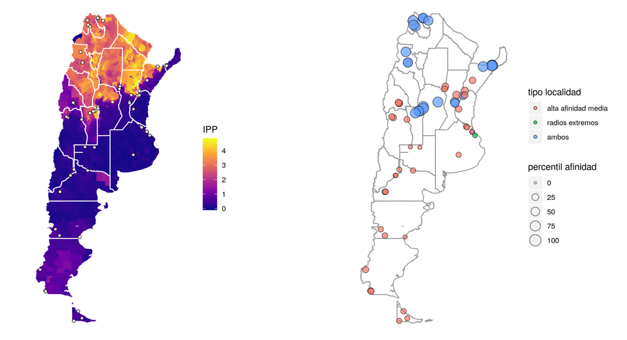

Localidadaes de alta afinidad con el Chagas

El proceso y los resultados fueron presentados en diversos congresos nacionales e internacionales, como en la *[2019 World Wide Web Conference](https://dl.acm.org/doi/10.1145/3308560.3316485)* (San Francisco, EEUU), en *[Data for Policy - 4th International Conference](http://dataforpolicy.org/)* (Londres, Reino Unido), en el [Encuentro Nacional de Chagas](https://www.paho.org/arg/index.php?option=com_content&view=article&id=10343:encuentro-nacional-de-chagas-argentina-actualiza-estrategia-para-lograr-la-eliminacion-de-la-transmision&Itemid=226) (Buenos Aires, Argentina) y en el [XIX Simposio Internacional sobre Enfermedades Desatendidas](https://www.mundosano.org/simposio/) (Buenos Aires, Argentina).

[figure not shown]

Presentando el proyecto en el XIX Simposio Internacional sobre Enfermedades Desatendidas

En los medios:

- [“Entrevista a Antonio Vázquez Brust, con Nora Bär”](https://radiocut.fm/audiocut/entrevista-a-antonio-vazquez-brust-con-nora-bar/)
- [“El impacto del big data en la práctica médica se verá en los próximos 5 a 10 años”](https://www.clarin.com/buena-vida/big-data-ia-proximos-10-anos-diagnosticos-rapidos-precisos-_0_5t-CIr6TL.html)
- [(Entrevista) “Antonio Vázquez Brust, líder del proyecto del Mapa de Chagas”](https://radiocut.fm/audiocut/antonio-vazquez-brust-lider-del-proyecto-del-mapa-de-chagas/)
- [“Mal de Chagas: cómo se construye el mapa con la situación en Argentina”](https://tn.com.ar/salud/lo-ultimo/mal-de-chagas-como-se-construye-el-mapa-con-la-situacion-en-argentina_893988)
- [“Comienzan a desarrollar un mapa de chagas de Argentina”](http://www.radionacional.com.ar/comienzan-a-desarrollar-un-mapa-de-chagas-de-argentina/)
- [“Usarán Big Data para detectar dónde se esconde el Chagas”](https://www.lavoz.com.ar/ciudadanos/usaran-big-data-para-detectar-donde-se-esconde-el-chagas)